# Coursera reproducible research

Giuseppe Fumarola

2/11/2020

## Load the database

The database is loaded from the local directory and stored as “activity”. Relevant libraries are loaded

```r
activity <- read.csv("~/R/R-coursera/repdata_data_activity/activity.csv")
library(dplyr)
```

```r
library(ggplot2)
```

## Preprocess the data

The variable “date” is formatted to become an object of class “date”.

```r
activity$date <- as.Date(activity$date)
```

## Number of steps per day

Calculate a table for total steps per day

```r
dailysteps <- activity %>% group_by(date) %>% summarise(steps = sum(steps))
dailysteps
```

```
## # A tibble: 61 x 2
##    date       steps
##    <date>     <int>
##  1 2012-10-01    NA
##  2 2012-10-02   126
##  3 2012-10-03 11352
##  4 2012-10-04 12116
##  5 2012-10-05 13294
##  6 2012-10-06 15420
##  7 2012-10-07 11015
##  8 2012-10-08    NA
##  9 2012-10-09 12811
## 10 2012-10-10  9900
## # ... with 51 more rows
```

## Barchart of steps per day

Plotting a chart which shows the number of total steps per day

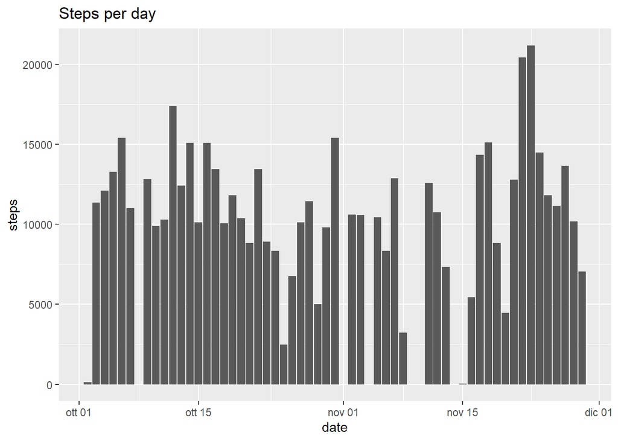

```r
daysteps <- ggplot(dailysteps, aes(x = date, y = steps))
daysteps + geom_col() + ggtitle("Steps per day")
```

## Daily steps stats

```r
mean_steps <- round(mean(dailysteps$steps, na.rm = TRUE))
median_steps <- median(dailysteps$steps, na.rm = TRUE)
stats_steps <- matrix(data = rbind(mean_steps, median_steps),
                     nrow = 1, ncol = 2)
colnames(stats_steps) <- c("Mean", "Median")
```

## Average daily activity pattern

The following code creates a table with the average walking activity per time interval.

```r
avg_daily_activity <- activity %>% group_by(interval) %>%
  summarize(steps = mean(steps, na.rm = TRUE))
```

Evidence from the table is used to plot the information.

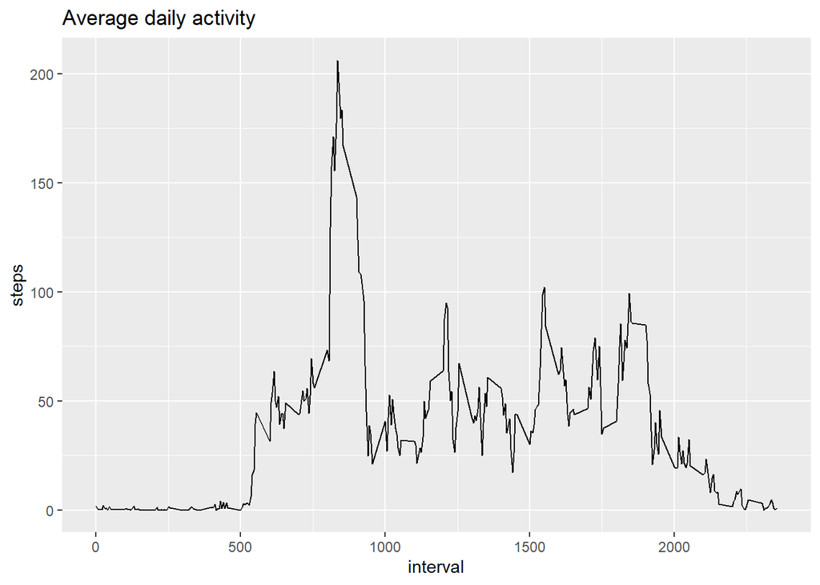

```r
avgline <- ggplot(avg_daily_activity, aes(interval, steps)) +
           geom_line() + ggtitle("Average daily activity")
avgline
```

The following code retrieves the most active interval of the day, on average.

```r
avg_daily_activity[order(-avg_daily_activity$steps),][1,]
```

```
## # A tibble: 1 x 2
##   interval steps
##      <int> <dbl>
## 1      835  206.
```

## Counting missing values

It seems that the dataframe contain 2304 missing measurements of the variable “steps”.

```r
sum(is.na(activity$steps))
```

```
## [1] 2304
```

## Dealing with missing values missing values

The quick analysis reported below reveals that missing values are present only in 8 specific days, where no measurements have been taken. Therefore, the best strategy to tackle this issue seems to impute to each time interval in all of these missing days the average number of steps for that time interval. The intended result is that the missing days would mirror a “standard” day.

```r
nactivity <- subset(activity, is.na(steps))
table(nactivity$date)
```

```
##
## 2012-10-01 2012-10-08 2012-11-01 2012-11-04 2012-11-09 2012-11-10 2012-11-14
##        288        288        288        288        288        288        288
## 2012-11-30
##        288
```

## Compiling a new database

“activity2” is a copy of the original database. However, the follwing function assign a value to each and every missing value, according to the strategy described above.

```r
activity2 <- activity

for (i in 1:dim(activity2)[1]) {
     if (is.na(activity2[i,1]) == TRUE) {
         index <- match(activity2[i,3],avg_daily_activity$interval)
         activity2[i,1] <- avg_daily_activity[index,2]
     }
  }
```

## Impact of filling the missing values

The new bar chart shows that the procedure did not have a significant impact on the trend. The bars which still looks empty are due not anymore to missing values, but to very low values recorded in these days.

```r
dailysteps2 <- activity2 %>% group_by(date) %>% summarise(steps = sum(steps))
```

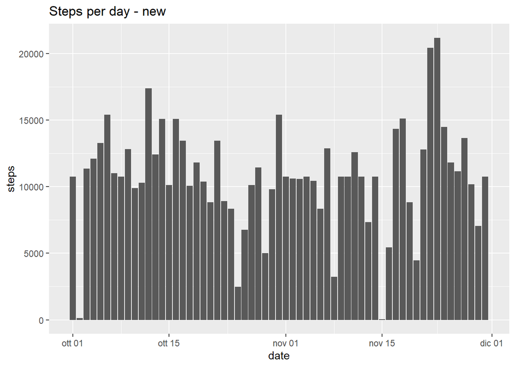

```r
daysteps2 <- ggplot(dailysteps2, aes(x = date, y = steps))
daysteps2 + geom_col() + ggtitle("Steps per day - new")
```

```r
mean_steps2 <- round(mean(dailysteps2$steps, na.rm = TRUE))
median_steps2 <- median(dailysteps2$steps, na.rm = TRUE)
stats_steps2 <- matrix(data = rbind(mean_steps2, median_steps2),nrow = 1, ncol = 2)
colnames(stats_steps2) <- c("Mean", "Median")
stats_steps2
```

```
##       Mean   Median
## [1,] 10766 10766.19
```

## Create a factorial variable for weekday

The following code identifies each entry as being recorded on a weekday or a weekend (saturday or sunday).

```r
activity2$day <- weekdays(activity2$date)
days <- unique(activity2$day)

for (i in 1:dim(activity2)[1])
     {if (activity2[i,4] %in% days[1:5]) {
         activity2[i,5] <- "weekday"}
      else {activity2[i,5] <- "weekend"}
}

activity2$V5 <- as.factor(activity2$V5)
```

## Plotting weekday vs weekend

The following code creates a chart to show daily activity in different days of the week.

```r
avg_wd_activity <- subset(activity2, V5 == "weekday") %>%
    group_by(interval) %>% summarize(steps = mean(steps, na.rm = TRUE))
avg_wd_activity$weekpart <- "weekday"

avg_we_activity <- subset(activity2, V5 == "weekend") %>%
    group_by(interval) %>% summarize(steps = mean(steps, na.rm = TRUE))
```

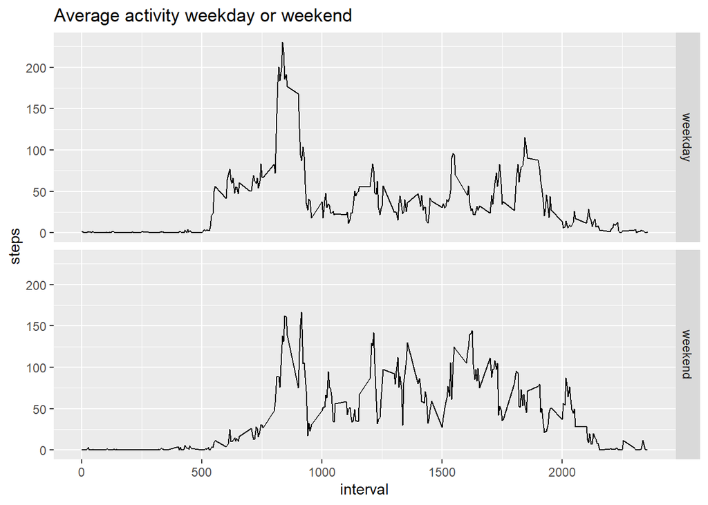

```r
avg_we_activity$weekpart <- "weekend"

avg_activity <- rbind(avg_wd_activity, avg_we_activity)

avgline <- ggplot(avg_activity, aes(interval, steps)) +
 geom_line() + ggtitle("Average activity weekday or weekend") +
 facet_grid(weekpart ~ .)

avgline
```